[figure not shown]

# Travaux pratiques notés

## Consignes pour les étudiants

**- En cas de problème**

- Tout d'abord, redémarrer le noyau (dans la barre de menus, sélectionnez **`Noyau -> Redémarer`** ou **`Kernel -> Restart`**).
- Puis exécuter toutes les cellules (dans la barre de menus, sélectionnez **`Cellule -> Executer tout`** ou **`Cellule -> Run All`**).

**- Binôme de travail**  
Ce travail doit être réalisé en binôme.

**- Soins des réponses**

- **Commenter le code**, utiliser des cellules de Markdown pour **expliciter** et commenter les résultats.
- **Rappeler les formules** qui sont utilisées. Ceci sera pris en compte dans la notation.
- Mettre **titre**, **légendes** sur les figures.

**- Exécuter la cellule suivante:**

```python
import random
import numpy as np
import matplotlib.pyplot as plt
import pandas as pd
import scipy.stats as st

# Vous pouvez ajouter des packages classiques si nécessaires.
```

**- Veuillez remplir vos prénoms, noms et numéros étudiant dans la cellule suivante:**

```python
# Elève 1
# Nom : ADAM
# Prénom : Oumar Adam
# Numéro étudiant: 12110686

# Elève 2
# Nom : DIALLO
# Prénom :Mamadou Alpha
# Numéro étudiant:12212398
```

## Exercice 1 - Statistiques descriptives

Veuillez exécuter cette cellule:

```python
df_foot = pd.read_csv("StatCDM.csv", sep=';')
```

**1.** Dans cet exercice, nous avons un jeu de données sur les 36 pays ayant le plus participé à la coupe du monde de football.

- Donner les différentes variables et leur nature (quantitative, qualitative, discrète, continue).
- Tracer l'histogramme du nombre de victoires (indiquées par la colonne *'G'*). On utilisera pour la hauteur des rectangles l'effectif de la classe.
- Donner les effectifs de la variable *'Participation'* (et le(s) mode(s)).

# Question 1.1

Variables et leur nature :

- Rang: Quantitative, discrète (numéro de classement).
- Pays: Qualitative, nominale (nom des pays).
- Continent: Qualitative, nominale (nom des continents).
- Participation: Quantitative, discrète (nombre de participations).
- Matchs: Quantitative, discrète (nombre de matchs joués).
- G (Victoires): Quantitative, discrète (nombre de victoires).
- N (Matchs nuls): Quantitative, discrète (nombre de matchs nuls).
- P (Défaites): Quantitative, discrète (nombre de défaites).
- BP (Buts marqués): Quantitative, continue (nombre de buts marqués).
- BC (Buts encaissés): Quantitative, continue (nombre de buts encaissés).
- Diff (Différence de buts): Quantitative, continue (différence de buts).
- Pts (Points): Quantitative, discrète (nombre de points).
- Finales: Quantitative, discrète (nombre de finales atteintes).
- Trophes: Quantitative, discrète (nombre de trophées remportés).

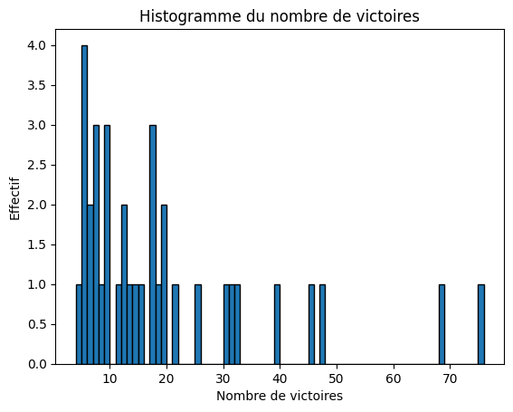

```
Effectifs de la variable 'Participation':
Participation
6     6
11    4
8     4
9     4
16    3
7     3
18    2
14    2
12    2
22    1
20    1
17    1
13    1
3     1
4     1
Name: count, dtype: int64

Mode(s) de la variable 'Participation':
0    6
Name: Participation, dtype: int64
```

```python
# question 1.2

# Données
victoires = df_foot['G']

# Tracé de l'histogramme
plt.hist(victoires, bins=range(min(victoires), max(victoires) + 1), edgecolor='black')
plt.title("Histogramme du nombre de victoires")
plt.xlabel("Nombre de victoires")
plt.ylabel("Effectif")
plt.show()

# Question 1.3

# Adam Aysoy roumine 1
# Effectifs de la variable 'Participation'
effectifs_participation = df_foot['Participation'].value_counts()

# Mode(s)
modes_participation = df_foot['Participation'].mode()

print("Effectifs de la variable 'Participation':")
print(effectifs_participation)

print("\nMode(s) de la variable 'Participation':")
print(modes_participation)
```

**2.** On va se concentrer sur la variable *'Participation'*.

- Trouver la moyenne et la variance (non-biaisée) du nombre de participations pour les pays européens et les pays d'Amérique du sud.
- Tracer le diagramme circulaire de participations par continent.
- Pour les pays ayant joué des finales, tracer le nuage de points avec en abscisses le nombre de partipations et en ordonnées le nombre de finales.

```python
# Question 2.1 : Moyenne et variance


# Filtre pour les pays européens
europe_df = df_foot[df_foot['Continent'] == 'Europe']

# Filtre pour les pays d'Amérique du Sud
amerique_sud_df = df_foot[df_foot['Continent'] == 'Amerique - S']

# Moyenne et variance pour l'Europe
moyenne_europe = europe_df['Participation'].mean()
variance_europe = europe_df['Participation'].var()

# Moyenne et variance pour l'Amérique du Sud
moyenne_amerique_sud = amerique_sud_df['Participation'].mean()
variance_amerique_sud = amerique_sud_df['Participation'].var()

print("Moyenne et variance du nombre de participations pour les pays européens :")
print("Moyenne Europe:", moyenne_europe)
print("Variance Europe:", variance_europe)

print("\nMoyenne et variance du nombre de participations pour les pays d'Amérique du Sud :")
print("Moyenne Amérique du Sud:", moyenne_amerique_sud)
print("Variance Amérique du Sud:", variance_amerique_sud)
```

```
Moyenne et variance du nombre de participations pour les pays européens :
Moyenne Europe: 11.421052631578947
Variance Europe: 18.257309941520468

Moyenne et variance du nombre de participations pour les pays d'Amérique du Sud :
Moyenne Amérique du Sud: 12.5
Variance Amérique du Sud: 37.142857142857146
```

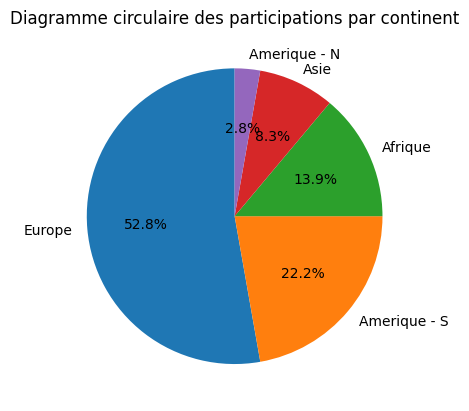

```python
#question 2.2
# Calcul des effectifs par continent
effectifs_continent = df_foot['Continent'].value_counts()

# Tracé du diagramme circulaire
plt.pie(effectifs_continent, labels=effectifs_continent.index, autopct='%1.1f%%', startangle=90)
plt.title("Diagramme circulaire des participations par continent")
plt.show()
```

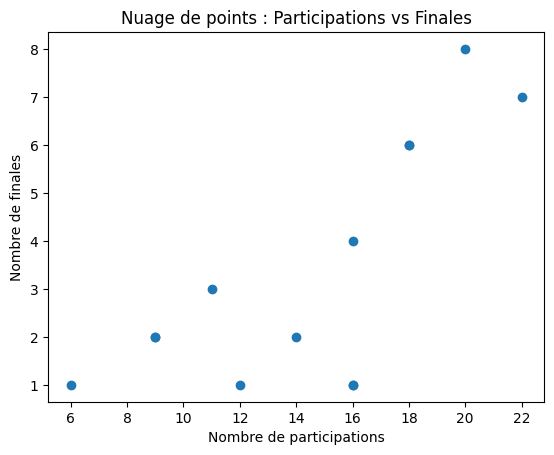

```python
# Question 2.3: Diagrammes et nuage de points
# Filtre pour les pays ayant joué des finales
finales_df = df_foot[df_foot['Finales'] > 0]

# Tracé du nuage de points
plt.scatter(finales_df['Participation'], finales_df['Finales'])
plt.title("Nuage de points : Participations vs Finales")
plt.xlabel("Nombre de participations")
plt.ylabel("Nombre de finales")
plt.show()
```

**3.** Quelques boîtes à moustaches :

- Tracer la boite à moustache des pays africains des variables "*Rang*", "*Participation*" et "*Matchs*".
- Même question pour les pays asiatiques.

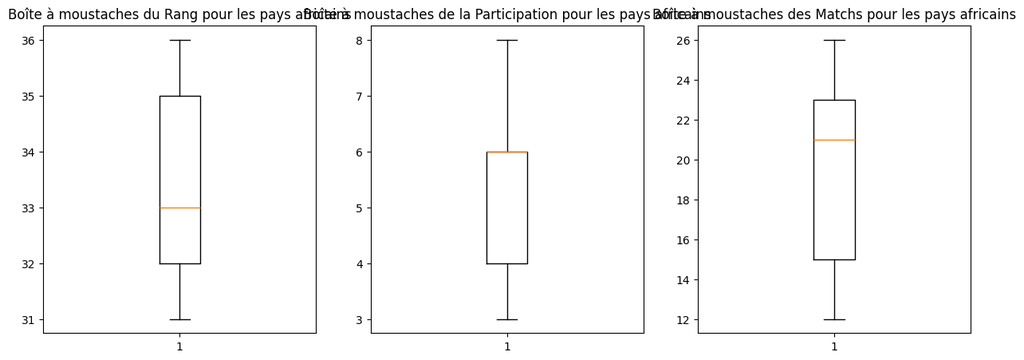

```python
# Question 3.1
# Filtre pour les pays africains
afrique_df = df_foot[df_foot['Continent'] == 'Afrique']

# Tracé des boîtes à moustaches
plt.figure(figsize=(15, 5))

# Boîte à moustaches pour le Rang
plt.subplot(1, 3, 1)
plt.boxplot(afrique_df['Rang'])
plt.title("Boîte à moustaches du Rang pour les pays africains")

# Boîte à moustaches pour la Participation
plt.subplot(1, 3, 2)
plt.boxplot(afrique_df['Participation'])
plt.title("Boîte à moustaches de la Participation pour les pays africains")

# Boîte à moustaches pour les Matchs
plt.subplot(1, 3, 3)
plt.boxplot(afrique_df['Matchs'])
plt.title("Boîte à moustaches des Matchs pour les pays africains")

plt.show()
```

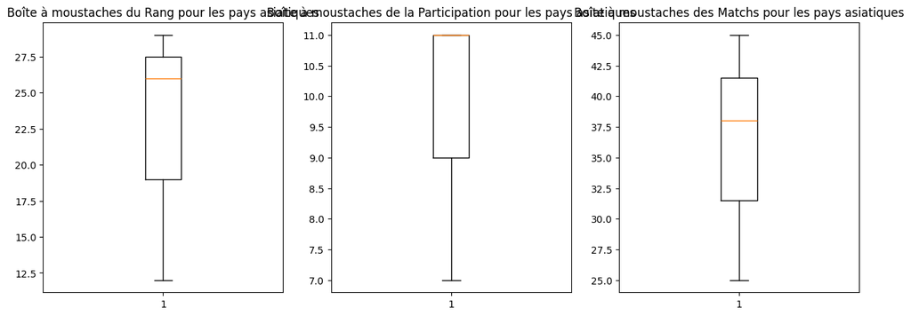

```python
#question 3.2
# Filtre pour les pays asiatiques
asie_df = df_foot[df_foot['Continent'] == 'Asie']

# Tracé des boîtes à moustaches
plt.figure(figsize=(15, 5))

# Boîte à moustaches pour le Rang
plt.subplot(1, 3, 1)
plt.boxplot(asie_df['Rang'])
plt.title("Boîte à moustaches du Rang pour les pays asiatiques")
# Boîte à moustaches pour la Participation
plt.subplot(1, 3, 2)
plt.boxplot(asie_df['Participation'])
plt.title("Boîte à moustaches de la Participation pour les pays asiatiques")

# Boîte à moustaches pour les Matchs
plt.subplot(1, 3, 3)
plt.boxplot(asie_df['Matchs'])
plt.title("Boîte à moustaches des Matchs pour les pays asiatiques")

plt.show()
```

**4.** Régression linéaire

- Pour les pays ayant participé à une finale, calculer la corrélation entre les variables *'Participation'*, *'Matchs'*, *'Finales'*, *'Trophes'*.
- Rappeler la formule de la régression linéaire et calculer les coefficients pour les variables $x=$ *'Participation'* et $y=$ *'Trophés'* (pays ayant joué au moins une finale).
- Tracer la droite de régression linéaire entre *'Participation'* et *'Trophes'* (pays ayant joué au moins une finale).
- Combien faudrait-il de participations pour espérer remporter un titre d'après le modèle ? Commentaire.

```python
# Question 4.1
# Filtre pour les pays ayant participé à une finale
finales_df = df_foot[df_foot['Finales'] > 0]

# Calcul de la corrélation
correlation_matrix = finales_df[['Participation', 'Matchs', 'Finales', 'Trophes']].corr()

print("Matrice de corrélation :")
print(correlation_matrix)
```

```
Matrice de corrélation :
               Participation    Matchs   Finales   Trophes
Participation       1.000000  0.970216  0.750469  0.896235
Matchs              0.970216  1.000000  0.828732  0.911071
Finales             0.750469  0.828732  1.000000  0.887933
Trophes             0.896235  0.911071  0.887933  1.000000
```

# Question 4.2

La formule de la régression linéaire pour ajuster une ligne droite à un ensemble de données est donnée par :

y = mx + b

où :

- (y) est la variable dépendante (dans notre cas, le nombre de trophées),
- (x) est la variable indépendante (dans notre cas, le nombre de participations),
- (m) est la pente de la ligne de régression,
- (b) est l'ordonnée à l'origine.

Les coefficients de la régression linéaire peuvent être calculés à l'aide des formules suivantes :

$m = \frac{n(\sum xy) - (\sum x)(\sum y)}{n(\sum x^2) - (\sum x)^2}$

$b = \frac{(\sum y) - m(\sum x)}{n}$

où (n) est le nombre d'observations, (\sum) représente la somme, (x) est la variable indépendante, (y) est la variable dépendante, et (xy) est le produit des deux.

```python
df_foot = pd.read_csv("StatCDM.csv", sep=';')
participations = df_foot['Participation']
trophees = df_foot['Trophes']
participations = np.array(participations)
trophees = np.array(trophees)

# Calcul des coefficients de la régression linéaire
n = len(participations)
sum_x = np.sum(participations)
sum_y = np.sum(trophees)
sum_xy = np.sum(participations * trophees)
sum_x_squared = np.sum(participations ** 2)

# Calcul des coefficients
m = (n * sum_xy - sum_x * sum_y) / (n * sum_x_squared - sum_x ** 2)
b = (sum_y - m * sum_x) / n

m, b
```

```
(0.218303946263644, -1.7174643157010914)
```

```python
#question 4.3
# Calcul des coefficients de la régression linéaire
n = len(finales_df)
sum_x = finales_df['Participation'].sum()
sum_y = finales_df['Trophes'].sum()
sum_xy = (finales_df['Participation'] * finales_df['Trophes']).sum()
sum_x_squared = (finales_df['Participation'] ** 2).sum()

# Coefficients de la régression linéaire
m = (n * sum_xy - sum_x * sum_y) / (n * sum_x_squared - sum_x**2)
b = (sum_y - m * sum_x) / n

print("Coefficients de la régression linéaire :")
print("Coefficient de pente (m) :", m)
print("Ordonnée à l'origine (b) :", b)
```

```
Coefficients de la régression linéaire :
Coefficient de pente (m) : 0.3401943967981704
Ordonnée à l'origine (b) : -3.20125786163522
```

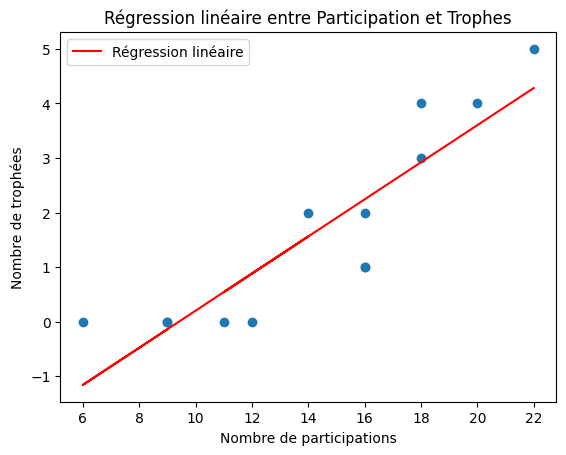

```python
#question 4.4
# Tracé de la droite de régression linéaire
plt.scatter(finales_df['Participation'], finales_df['Trophes'])
plt.plot(finales_df['Participation'], m * finales_df['Participation'] + b, color='red', label='Régression linéaire')
plt.title("Régression linéaire entre Participation et Trophes")
plt.xlabel("Nombre de participations")
plt.ylabel("Nombre de trophées")
plt.legend()
plt.show()
```

La formule de la régression linéaire simple est donnée par l'équation : [ y = mx + b ]

## Exercice 2 - Collectionneur de carte pokémon

Pour doper ses ventes, une marque de chocolat cache dans chaque tablette une carte pokémon parmi les $N$ cartes au total. On suppose que les cartes présentes dans les tablettes sont indépendamment et uniformément choisies parmi les $N$ cartes existantes. On cherche à déterminer combien de tablettes il faut acheter pour obtenir l'entièreté de la collection.

On note $X$ le nombre de tablettes à acheter pour compléter la collection.

On utilise la notation $H(N) = \sum_{n=1}^N \frac{1}{n}$ et $H_2(N) = \sum_{n=1}^N \frac{1}{n^2}$ .

```python
# On donne les fonctions suivantes :
def H(N):
    return(np.sum(1/(np.arange(N)+1)))
def H2(N):
    return(np.sum(1/(np.arange(N)+1)**2))
```

1. On note $X_k$ (avec $1 \leq k \leq N$) le nombre de tablettes à acheter pour pouvoir enfin obtenir une $k$-ième nouvelle figure dans l'album. Déterminer la loi de $X_k$.
- Tracer sa fonction de répartition en fixant le paramètre à une valeur qui sera précisée.

La variable $X_k$ suit une loi géométrique. En effet, $X_k$ représente le nombre de tentatives nécessaires pour obtenir un succès (c’est-à-dire une nouvelle carte) dans une série d’essais de Bernoulli indépendants. Chaque essai correspond à l’achat d’une tablette de chocolat. La probabilité de succès à chaque essai est de $\frac{N−k+1}{N}$ , car il y a $N−k+1$ nouvelles cartes que le collectionneur n’a pas encore obtenues parmi les $N$ cartes possibles. La fonction de masse de probabilité de la loi géométrique est donnée par : $P(X_k=x)=(1−p)x−1p$ où $x$ est le nombre d’essais, et p est la probabilité de succès à chaque essai. La fonction de répartition, qui donne la probabilité que $X_k$ prenne une valeur inférieure ou égale à x, est donnée par : $F(x)=1−(1−p)^x$

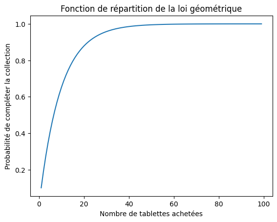

```python
def geom_cdf(x, p):
    return 1 - (1-p)**x

x = np.arange(1, 100)
p = 1/N

plt.plot(x, geom_cdf(x, p))
plt.xlabel('Nombre de tablettes achetées')
plt.ylabel('Probabilité de compléter la collection')
plt.title('Fonction de répartition de la loi géométrique')
plt.show()
```

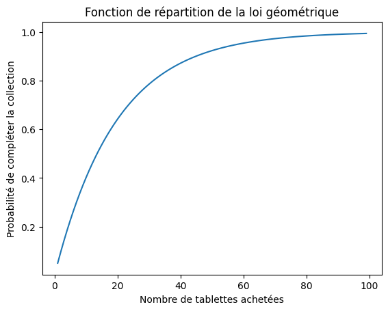

```python
# test pour N = 20
def geom_cdf(x, p):
    return 1 - (1-p)**x

x = np.arange(1, 100)
p = 1/20

plt.plot(x, geom_cdf(x, p))
plt.xlabel('Nombre de tablettes achetées')
plt.ylabel('Probabilité de compléter la collection')
plt.title('Fonction de répartition de la loi géométrique')
plt.show()
```

2. En déduire $E(X)$ et $V(X)$.
- Justifier par un calcul leurs valeurs.
- Ecrire deux fonctions python qui calculent ces valeurs.

```python
def moyenne_X(N):
    return N * H(N)

def variance_X(N):
    return H2(N) / N**2
```

3. *Question numérique* : Développer un algorithme pour génerer des tirages de la loi de $X$. Pour un nombre de cartes donné $N$, la fonction renvoie le nombre de tablettes achetées pour compléter la collection (ceci ne renvoie pas l'espérance mais un tirage).

```python
# Question 3




def collection(N):
    collection = set()
    count = 0
    while len(collection) < N:
        card = np.random.randint(1, N+1)  # Génère une carte aléatoire
        collection.add(card)
        count += 1
    return count

N = 20
resultat_tirage = collection(N)
print(f"Nombre de tablettes nécessaires pour compléter la collection : {resultat_tirage}")
```

```
Nombre de tablettes nécessaires pour compléter la collection : 53
```

```python
N = 20
Data_pokemon = [collection(N) for i in range (1,10000)]
print(Data_pokemon)
```

[output not shown]

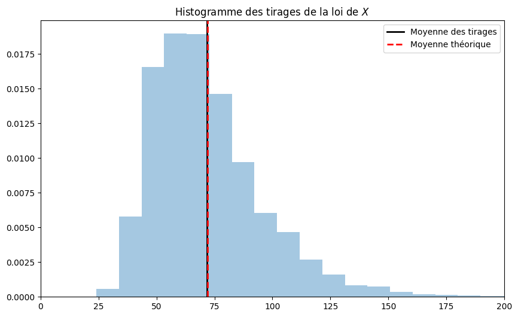

```python
plt.figure(figsize=(10,6))
plt.hist(Data_pokemon,bins=20,density=True,alpha=0.4)
plt.axvline(np.mean(Data_pokemon),color='black',linewidth=2,label='Moyenne des tirages')
plt.title('Histogramme des tirages de la loi de $X$')
plt.axvline(moyenne_X(N),color='red',linestyle='--',linewidth=2,label='Moyenne théorique')
plt.legend()
plt.xlim([0,200])
plt.show()
```

```python
print('La moyenne théorique est')
print(moyenne_X(N))
print('La moyenne des simulations est')
print(np.mean(Data_pokemon))
```

```
La moyenne théorique est
71.95479314287364
La moyenne des simulations est
71.87508750875088
```

```python
print('La variance théorique est')
print(variance_X(N))
print('La variance des simulations est')
print(np.var(Data_pokemon))
```

```
La variance théorique est
0.003990408109782558
La variance des simulations est
569.3874371735603
```

## Exercice 3 - Intervalle de confiance d'une proportion

Exécuter la commande qui suit pour générer les données à étudier:

```python
# Generation des donnees
random.seed(24112023) # Seed aleatoire
taille = 1500 # Nbre de donnees
poids_votes = [1.15,1] # Biai des votes
votes = random.choices(['Bill', 'Tom'], weights=poids_votes, k=taille) # Generation donnees votes
df_election = pd.DataFrame({'Vote': votes}) # Creation dataframe
print(df_election)
```

```
      Vote
0     Bill
1      Tom
2     Bill
3     Bill
4     Bill
...    ...
1495  Bill
1496  Bill
1497  Bill
1498  Bill
1499   Tom

[1500 rows x 1 columns]
```

1. On simule ici un résultat d'un sondage sur 1500 personnes.
- Quel est la loi qui modélise cette expérience ?
- On s'intéresse donc à estimer la proportion de vote pour le candidat Bill. Quel est l'estimateur de la proportion ?
- Donner alors pour l'échantillon la proportion voulue et l'écart type associé ?

C'est une loi binomiale.Chaque personne interrogée dans le sondage a deux choix possibles (voter pour Bill ou Tom), les votes sont indépendants et la probabilité de voter pour Bill est la même pour chaque personne. L'estimateur de la proportion de votes pour Bill est la moyenne des votes pour Bill dans l'échantillon. C'est-à-dire le nombre total de votes pour Bill divisé par la taille de l'échantillon. Pour calculer la proportion de votes pour Bill dans l'échantillon, on peut compter le nombre de votes pour Bill et le diviser par la taille de l'échantillon. Pour calculer l'écart type associé, on peux utiliser la formule de l'écart type pour une distribution binomiale, qui est $\sqrt{np(1-p)}$, où $n$ est la taille de l'échantillon et $p$ est la proportion de votes pour Bill.

```python
# Question 1

votes_bill = np.sum(df_election['Vote'] == 'Bill')
proportion_bill = votes_bill / taille
ecart_type = np.sqrt(taille * proportion_bill * (1 - proportion_bill))

print("Proportion de votes pour Bill :", proportion_bill)
print("Ecart type :", ecart_type)
```

```
Proportion de votes pour Bill : 0.522
Ecart type : 19.346162410152562
```

2. Quels sont les intervalles de confiances pour cette proportion de votes:
- à 90 %
- à 95 %
- à 99 %

Que peut-on conclure ?

L'intervalle de confiance pour une proportion est donné par la formule : $$p \in \left[ x - \frac{\sqrt{x(1 - x)}}{\sqrt{n}} z_{\frac{\alpha}{2}}, x + \frac{\sqrt{x(1 - x)}}{\sqrt{n}} z_{\frac{\alpha}{2}} \right]$$

```python
# Question 2
# Adam Aysoy roumine 3
def confidence_interval(proportion, n, alpha):
    z = st.norm.ppf(1 - alpha/2)
    delta = z * np.sqrt(proportion * (1 - proportion) / n)
    return proportion - delta, proportion + delta

votes_bill = np.sum(df_election['Vote'] == 'Bill')
proportion_bill = votes_bill / taille

confidence_90 = confidence_interval(proportion_bill, taille, 0.10)
confidence_95 = confidence_interval(proportion_bill, taille, 0.05)
confidence_99 = confidence_interval(proportion_bill, taille, 0.01)

print("Intervalle de confiance à 90% :", confidence_90)
print("Intervalle de confiance à 95% :", confidence_95)
print("Intervalle de confiance à 99% :", confidence_99)
```

```
Intervalle de confiance à 90% : (0.5007855963947122, 0.5432144036052878)
Intervalle de confiance à 95% : (0.4967214789580256, 0.5472785210419744)
Intervalle de confiance à 99% : (0.4887783919684752, 0.5552216080315248)
```

Les intervalles de confiance calculés nous donnent une estimation de la vraie proportion de votes pour Bill dans la population totale, basée sur notre échantillon. Plus le niveau de confiance est élevé, plus l'intervalle de confiance est large.

Si la proportion réelle de votes pour Bill se situe à l'intérieur de ces intervalles de confiance, cela signifie que notre échantillon est représentatif de la population totale à ce niveau de confiance. Par exemple, si la proportion réelle est dans l'intervalle de confiance à 95%, cela signifie que notre échantillon est représentatif de la population totale avec une confiance de 95%.

Cependant, il est important de noter que ces intervalles de confiance sont basés sur l'hypothèse que notre échantillon est un échantillon aléatoire simple de la population. Si ce n'est pas le cas (par exemple, si certaines personnes sont plus susceptibles d'être sondées que d'autres), alors ces intervalles de confiance peuvent ne pas être précis.

De plus, ces intervalles de confiance sont basés sur notre échantillon actuel. Si nous devions répéter le sondage avec un nouvel échantillon, nous obtiendrions probablement des intervalles de confiance légèrement différents.

Enfin, ces intervalles de confiance ne disent rien sur les votes pour Tom. Si nous voulons estimer la proportion de votes pour Tom, nous devrions calculer des intervalles de confiance séparés pour Tom.

3. Quelle taille d'échantillon faudrait-il pour que l'intervalle de confiance à 90% ait une largeur au plus de 2% ?
- Ecrire une fonction qui prend en argument le niveau de confiance, la taille maximale de l'intervalle de confiance souhaitée, $\delta$, pour renvoyer la taille minimale $n_{min}$ de l'échantillon qui respecte l'intervalle voulu.
- Vérifier le cas précédent.

La taille minimale de l'échantillon nécessaire pour obtenir un intervalle de confiance d'une certaine largeur peut être calculée en utilisant la formule de l'intervalle de confiance pour une proportion. En résolvant cette formule pour $n$, on obtient : $$n = \left(\frac{z_{\alpha/2}}{\delta/2}\right)^2 p(1-p)$$

```python
# Question 3
def min_sample_size(confidence, delta, p):
    z = st.norm.ppf(1 - (1 - confidence) / 2)
    n = (z / (delta / 2))**2 * p * (1 - p)
    return np.ceil(n)
# verification
n_min = min_sample_size(0.90, 0.02, proportion_bill)
print("Taille minimale de l'échantillon :", n_min)
```

```
Taille minimale de l'échantillon : 6751.0
```

## BONUS : Exercice 4 - Bandits à OK Corall

Soit $n \geq 1$ un entier. Deux groupes de bandits, chacun constitué de $n$ personnes, se retrouvent à OK Corral pour un règlement de comptes.

Tant qu’il reste au moins un bandit vivant dans chaque groupe, à chaque seconde un bandit (choisi uniformément au hasard parmi ceux encore vivants, indépendamment de tout ce qui s’est passé avant) abat un bandit de l'autre groupe.

On note $V(n)$ le nombre (aléatoire) de survivants à l’issue de la fusillade. Une étude théorique permet de montrer que $V(n)/n^{3/4}$ converge en loi lorsque $n \to \infty$ vers une variable aléatoire réelle à densité dont la densité est $$ \sqrt{\frac{3}{\pi}} x \exp^{\frac{-3x^4}{16}} 1_{[0,\infty(}(x) $$

**1.** Ecrire une fonction qui pour un $n$ renvoie le nombre de survivants, $V(n)$.

```python
# Question 1
def V(n):
    group1 = n
    group2 = n
    while group1 > 0 and group2 > 0:
        if np.random.rand() < 0.5:
            group1 -= 1
        else:
            group2 -= 1
    return group1 + group2
```

**2.** Ecrire une fonction qui pour $x$ renvoie la densité théorique évaluée en $x$.

```python
# Question 2
"""
def densite_bandit(x):
    if x < 0:
        return 0
    else:
        return np.sqrt(3/np.pi) * x * np.exp(-3 * x**4 / 16)
"""
def densite_bandit(x):
    return np.where(x < 0, 0, np.sqrt(3/np.pi) * x * np.exp(-3 * x**4 / 16))
```

**3.** Effectuer $1000$ simulations pour $n = 100$, $500$, $1000$ et illustrer par ces simulations la convergence en loi.

```python
#Question 3
%%time
Data100  = [V(100)/(100**(3/4)) for i in range (1,1000)]
Data500  = [V(500)/(500**(3/4)) for i in range (1,1000)]
Data1000 = [V(1000)/(1000**(3/4)) for i in range (1,1000)]
```

```
UsageError: Line magic function `%%time` not found.
```

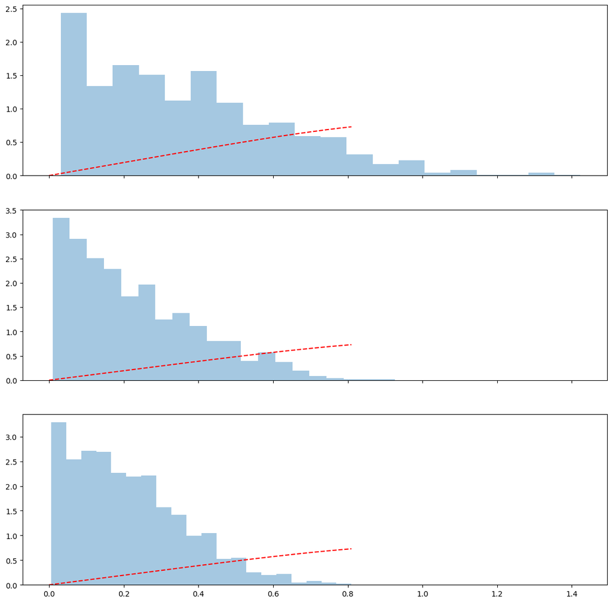

```python
Data100  = [V(100)/(100**(3/4)) for i in range (1,1000)]
Data500  = [V(500)/(500**(3/4)) for i in range (1,1000)]
Data1000 = [V(1000)/(1000**(3/4)) for i in range (1,1000)]
fig, axs = plt.subplots(3, 1, figsize=(14, 14), sharex=True)
Xvec = np.linspace(0, np.max(Data1000), int(1e4))

axs[0].hist(Data100, bins=20, density=True, alpha=0.4)
axs[0].plot(Xvec, densite_bandit(Xvec), 'r--')

axs[1].hist(Data500, bins=20, density=True, alpha=0.4)
axs[1].plot(Xvec, densite_bandit(Xvec), 'r--')

axs[2].hist(Data1000, bins=20, density=True, alpha=0.4)
axs[2].plot(Xvec, densite_bandit(Xvec), 'r--')

plt.show()
```